# IODS course project

Teppo Lindfors

# About the project

This course is about open data science, a mix of three overlapping integrities: 1) open data 2) open science and 3) data science

https://github.com/tlindfors/IODS-project/

# R Studio Exercise 2

### Q1. Reading and exploring the data the data

```r
lrn2014a <- read.csv("lrn2014a.csv", row.names = 1)
str(lrn2014a)
```

```
## 'data.frame':    166 obs. of  7 variables:
##  $ gender  : Factor w/ 2 levels "F","M": 1 2 1 2 2 1 2 1 2 1 ...
##  $ Age     : int  53 55 49 53 49 38 50 37 37 42 ...
##  $ Attitude: int  37 31 25 35 37 38 35 29 38 21 ...
##  $ deep    : num  3.58 2.92 3.5 3.5 3.67 ...
##  $ surf    : num  2.58 3.17 2.25 2.25 2.83 ...
##  $ stra    : num  3.38 2.75 3.62 3.12 3.62 ...
##  $ Points  : int  25 12 24 10 22 21 21 31 24 26 ...
```

```r
head(lrn2014a)
```

```
##   gender Age Attitude     deep     surf  stra Points
## 1      F  53       37 3.583333 2.583333 3.375     25
## 2      M  55       31 2.916667 3.166667 2.750     12
## 3      F  49       25 3.500000 2.250000 3.625     24
## 4      M  53       35 3.500000 2.250000 3.125     10
## 5      M  49       37 3.666667 2.833333 3.625     22
## 6      F  38       38 4.750000 2.416667 3.625     21
```

The dataset I am analysing is constructed based on a survey conducted in an introductory statistics course in University of Helsinki. It consists of the exam points and three different variables measuring respondents’ qualities as a student, along with data for some background characteristics. Overall, there are 166 observations (i.e., students) and 7 variables in the dataset.

### Q2. Graphical overview and summary statistics

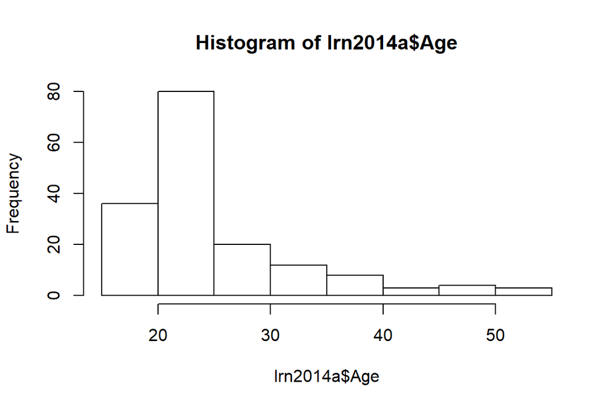

```r
hist(lrn2014a$Age)
```

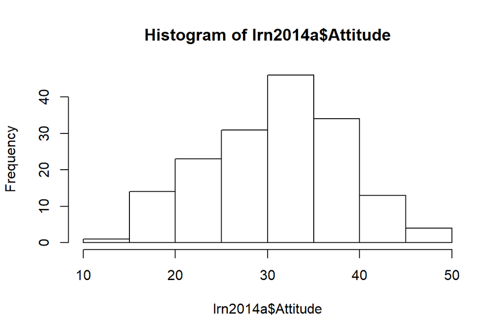

```r
hist(lrn2014a$Attitude)
```

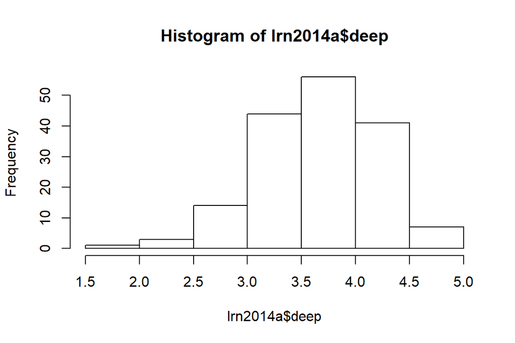

```r
hist(lrn2014a$deep)
```

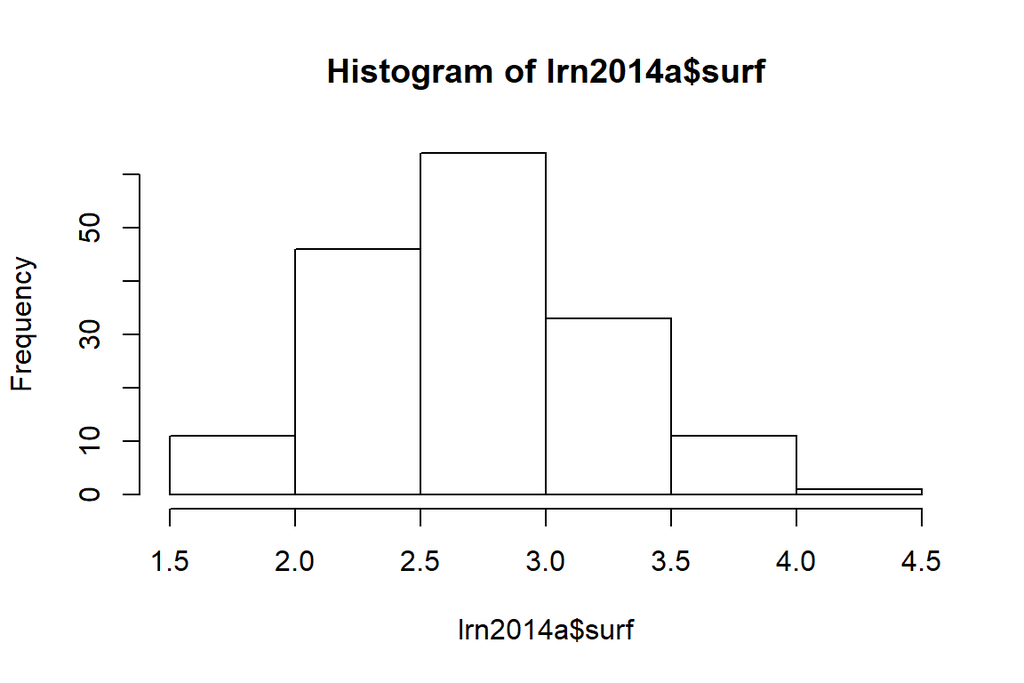

```r
hist(lrn2014a$surf)
```

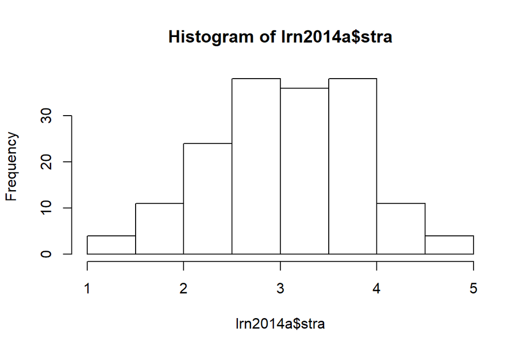

```r
hist(lrn2014a$stra)
```

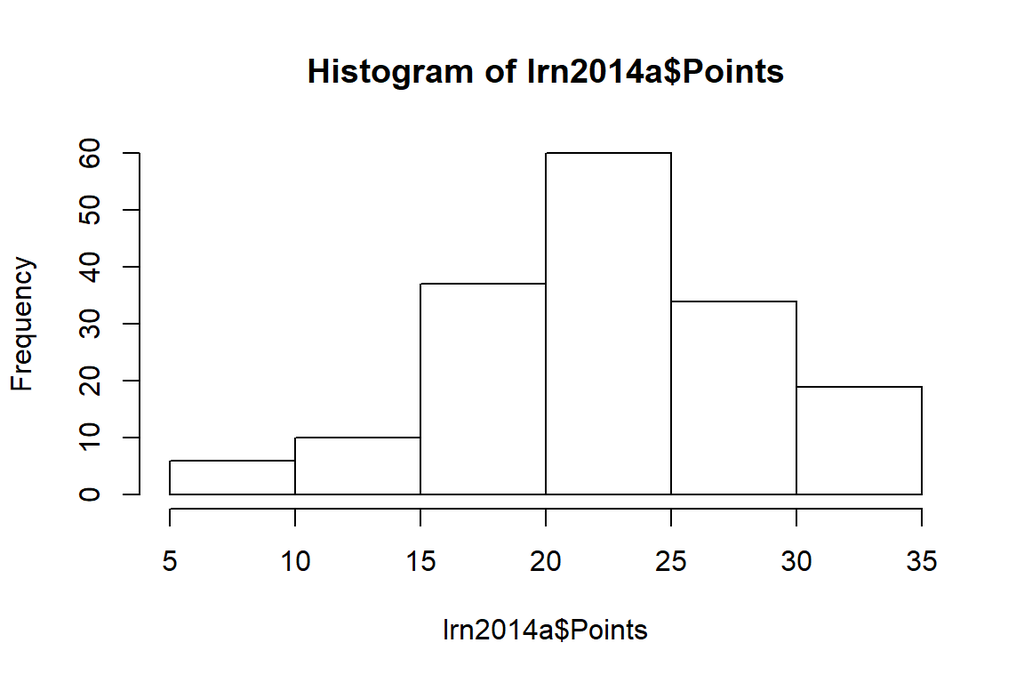

```r
hist(lrn2014a$Points)
```

```r
summary(lrn2014a$gender)
```

```
##   F   M
## 110  56
```

```r
summary(lrn2014a$Age)
```

```
##    Min. 1st Qu.  Median    Mean 3rd Qu.    Max.
##   17.00   21.00   22.00   25.51   27.00   55.00
```

```r
summary(lrn2014a$Points)
```

```
##    Min. 1st Qu.  Median    Mean 3rd Qu.    Max.
##    7.00   19.00   23.00   22.72   27.75   33.00
```

```r
sum(lrn2014a$gender == "F")/(sum(lrn2014a$gender == "F") +
                               sum(lrn2014a$gender == "M"))
```

```
## [1] 0.6626506
```

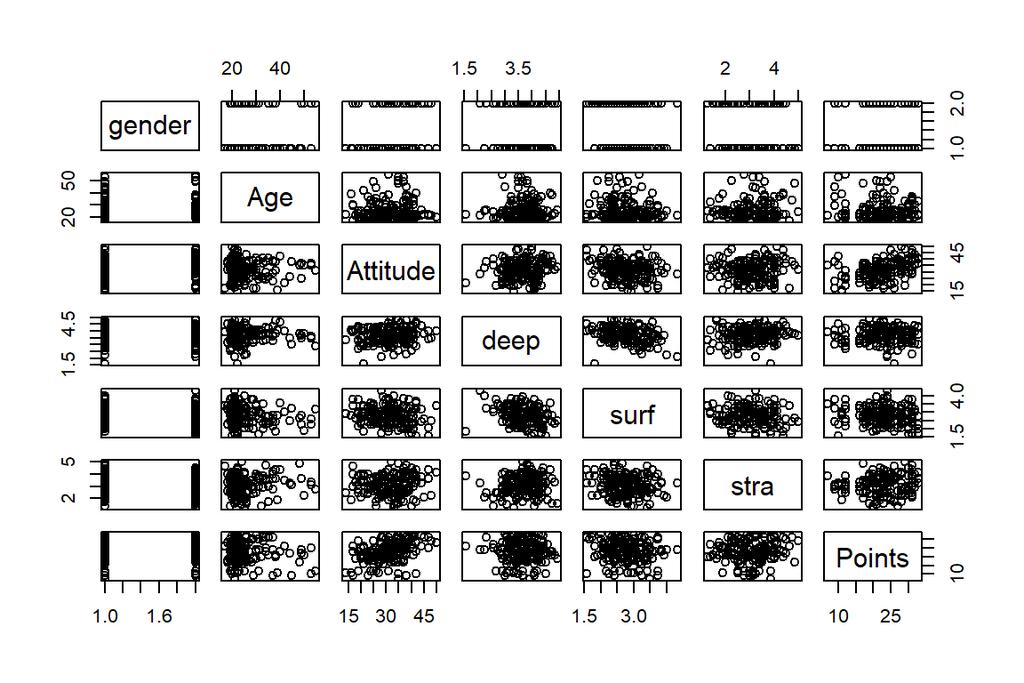

```r
pairs(lrn2014a)
```

```r
cor(lrn2014a$deep, lrn2014a$surf)
```

```
## [1] -0.323802
```

```r
cor(lrn2014a$Attitude, lrn2014a$Points)
```

```
## [1] 0.4365245
```

Typical student in the dataset is a young female. Indeed, the median respondent’s age is 22 years old, while circa 66% of the students identify themselves as females. As for the exam points and the variables measuring students’ learning qualities, they appear approximately normally distributed.

Considering connections between variables, it is hard distinguish clear cut linear relationships. Based on visual examination and simple correlation coefficients, too patterns could be pointed out, however. At first look, student’s attitude and exam points appear to be positively correlated, while their deep learning qualities and surface learning features are negatively correlated. This was expected.